# **MIDTERM PROJECT**

Andrew Sisitzky,Daniel Xu Guangze Yu,Yuyang Li

November 2nd 2021

**DATA WRANGLING**

## Data clean-Strawberries.csv

- Take apart strawberries.csv and restructure.
- Use **Year, State, Domain, Chemical, Chemical type, Value, units** as variable to get a new table.
- Select data when **Domain = “CHEMICAL”**.

## Data clean-Strawberries.csv

- Empty rows were removed to make the data more compact.
- The name of various pesticides were converted to uppercase letters for later matching.

## Data wrangling-left_join

- Function *left_join* is used to match the data by **“chemicaltype = pesticide”** .
- Combine them into one table for subsequent EDA.
- Delete the missing value if **“Year = NA”**.

**MAKE JUDGEMENTS**

## Give a number for toxins

- **For human**

- **For bee**

  | Chemical | 1 | 2 | 3 | 4 |
  | --- | --- | --- | --- | --- |
  | Bee.Toxins | unknown | slight | moderate | high |

## Calculate total toxins

- **For human**
  - Toxicity for human = *Carcinogen+HormoneDisruptor+Neurotoxins+ Developmental or Reproductive Toxins*
- **For bee**
  - Toxicity for bee = *Bee.Toxins*

**Topic we study**

- How the human-harm pesticide usage differ as time passes in the major strawberries producing areas in the US.

**EDA**

## Choose data to plot

- Select chemical types exist in **Pesticides.csv**.
- Filter dataframe into subsets in different measurements.
  - MEASURED IN LB / ACRE / YEAR AVG
  - MEASURED IN PCT OF AREA BEARING AVG
  - MEASURED IN LB
  - MEASURED IN LB / ACRE / APPLICATION AVG
  - MEASURED IN NUMBER AVG
- We chose subset of **MEASURED IN LB** for later analysis.

## Map of mean toxicity for human

- Created a map to visualize the mean toxicity for each state.
- Took data across all years, calculated the means, and plotted the results on a map of the United States.

## The map:

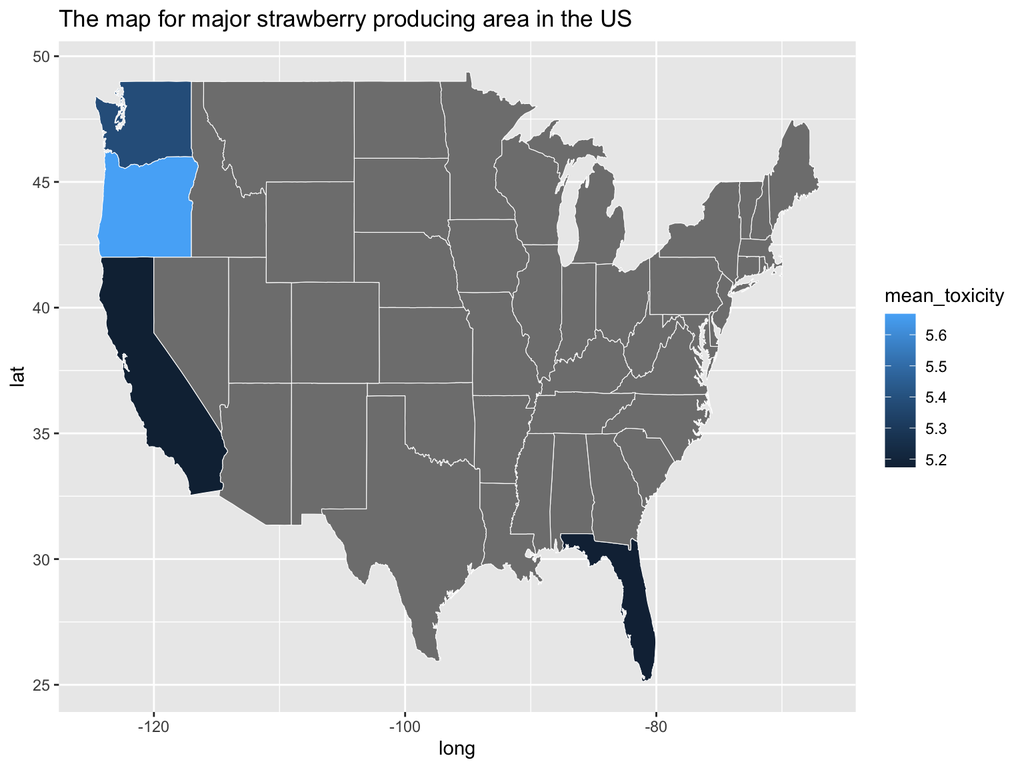

## Conclusion of map

- We found that California and Florida on average had lower human toxicity levels than Washington and Oregon.
- This plot shows that, based on this dataset, the harvests in Oregon tended to use chemicals that were rated higher by our toxicity scale in comparison to other states.

## Pesticides frequency

- For the first plot, we focused on frequency of total pesticides across 3 years.
- For the second plot, we looked at each chemical type and plotted its frequency of usage across 3 years.

## Total Pesticides frequency 2016 vs. 2018 vs. 2019

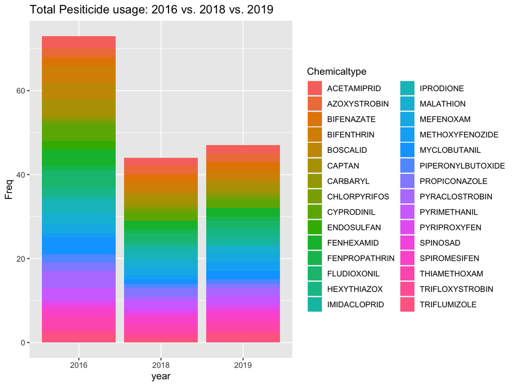

## Separate Pesticides frequency 2016 vs. 2018 vs. 2019

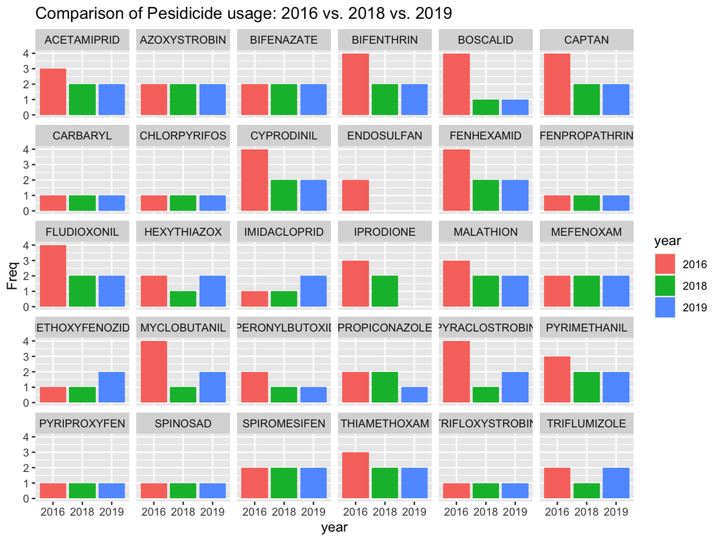

## Frequency of 5 toxicity levels for human

- Dive deeper into the distribution of toxicity level that related to human for each year.
- Using the toxicity levels we defined before.

## Frequency 2016

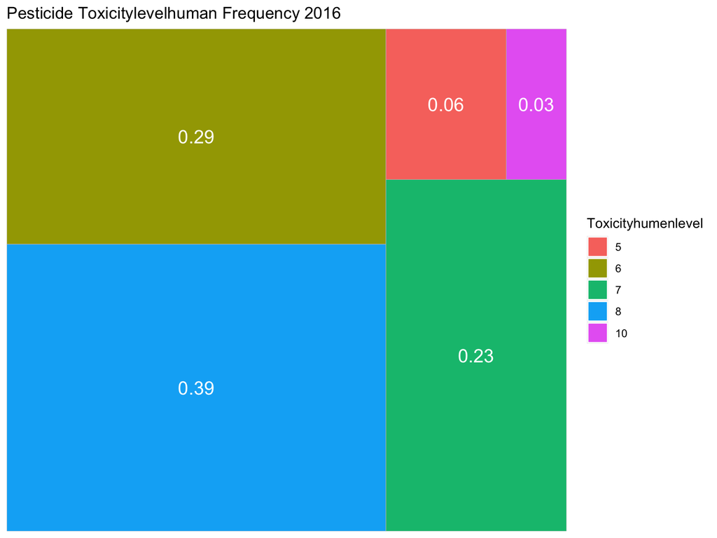

## Frequency 2018

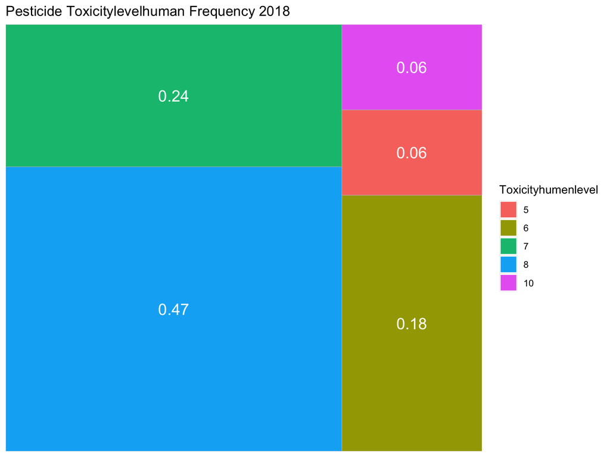

## Frequency 2019

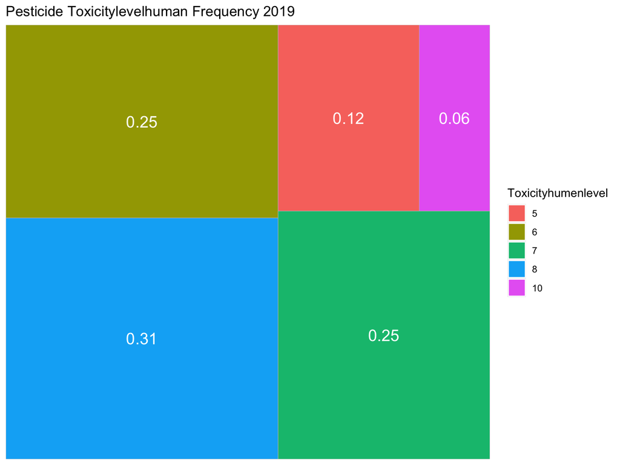

**Thank you!**